# Geog533 Lab 8

Li Xi

Complete the following exercises in Chapter 8 (Introduction to Regression Analysis) of the textbook [R] pages 247-250.

## Question 1

This is Exercise 1 in Chapter 8 of the Textbook [R].

A regression of weekly shopping trip frequency on annual income (data entered in thousands of dollars) is performed on data collected from 24 respondents. The results are summarized below:

- Intercept: 0.46
- Slope: 0.19

|  | Sum of squares | Degrees of freedom | Mean square | *F* |
| --- | --- | --- | --- | --- |
| Regression |  |  |  |  |
| Residual | 1.7 |  |  |  |
| Total | 2.3 |  |  |  |

### Question 1(a)

Fill in the blanks in the ANOVA table.

```r
n <- 24
```

[output not shown]

### Question 1(b)

What is the predicted number of weekly shopping trips for someone making $50,000/year?

```r
pred <- 0.46 + 0.19*(50000/1000)
pred
```

[output not shown]

### Question 1(c)

In words, what is the meaning of the coefficient 0.19? # For every increase in annual income equal to one thousand dollars, the predicted weekly shopping trip frequency for each respondant will rise by 0.19.

### Question 1(d)

Is the regression coefficient significantly different from zero? How do you know?

```r
crit_F <- qf(0.95,df1=1,df2=22)
F_value <- 0.6/(1.7/22)
if (F_value>crit_F){
  print("The regression coefficient is significantly different from 0")
}else{
  print("The regression coefficient is not significantly different from 0")
}
```

[output not shown]

### Question 1(e)

What is the value of the correlation coefficient?

```r
r_squared <- 0.6/2.3
r_squared
r_sqrt <- sqrt(r_squared)
r_sqrt
```

[output not shown]

## Question 2

This is Exercise 6 in Chapter 8 of the Textbook [R].

The following data are collected in an effort to determine whether snowfall is dependent upon elevation:

| Snowfall (inches) | Elevation (feet) |
| --- | --- |
| 36 | 400 |
| 78 | 800 |
| 11 | 200 |
| 45 | 675 |

Using R, show your work on exercises (a) through (g).

### Question 2(a)

Find the regression coefficients (the intercept and the slope coefficient).

```r
y <- c(36,78,11,45)
x <- c(400,800,200,675)
m <- lm(y~x)
result <- summary(m)
result
### intercept: -7.63721
### slope coefficient:  0.09665
```

[output not shown]

### Question 2(b)

Estimate the standard error of the residuals about the regression line.

```r
n <- length(y)
se <- sqrt(sum(residuals(m)^2)/(n-2))  # 11.252
se
```

```
[1] 11.25227
```

### Question 2(c)

Test the hypothesis that the regression coefficient associated with the independent variables is equal to zero. Also place a 95% confidence interval on the regression coefficient.

```r
confint(m)
```

```
                    2.5 %     97.5 %
(Intercept) -66.487337152 51.2129252
x            -0.006754067  0.2000541
```

### Question 2(d)

Find the value of $r^2$.

```r
R_squared <- 0.8899
adjusted_R_squared <- 0.8349
```

### Question 2(e)

Make a table of the observed values, predicted values, and the residuals.

```r
df <- data.frame(x,y)
df$predict <- fitted(m)
df$residual <- residuals(m)
library(knitr)
kable(df)
```

[output not shown]

### Question 2(f)

Prepare an analysis of variance table portraying the regression results.

```r
anova(m)
```

|  | Sum of squares | Degrees of freedom | Mean square | *F* |
| --- | --- | --- | --- | --- |
| Regression | 2047.7726301 | 1 | 2047.7726301 | 16.173 |
| Residual | 253.2273699 | 2 | 126.613685 |  |
| Total | 2301 | 3 |  |  |

### Question 2(g)

Graph the data and the regression line.

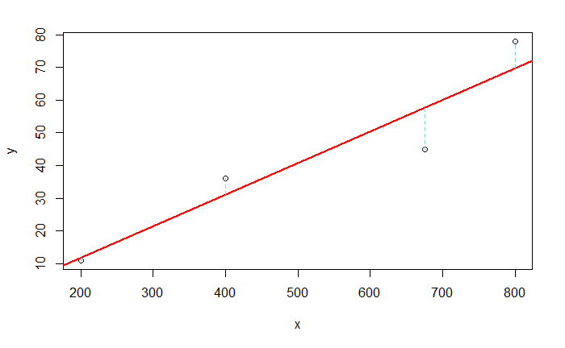

## Question 3

This is Exercise 10 in Chapter 8 of the Textbook [R].

Use R and the [Milwaukee dataset](http://spatial.binghamton.edu/geog533/data/Milwaukee_Sales.csv) to:

### Problem

perform a regression using sales price as the dependent variable and lot size as the independent variable.

### Solution

```r
df <- read.csv("http://spatial.binghamton.edu/geog533/data/Milwaukee_Sales.csv")
X <- df$LotSize
Y <- df$SalePrice
m <- lm(Y~X)
summary(m)
plot(Y~X)
abline(m,col="red",lwd=2)
segments(X,fitted(m),X,Y,col='skyblue',lty="dashed")
```

[output not shown]

## Question 4

This is Exercise 11 in Chapter 8 of the Textbook [R].

Use R and the Hypothetical [UK Housing Prices dataset](http://spatial.binghamton.edu/geog533/data/UK_Housing.csv) to:

### Question 4(a)

perform a regression using house price as the dependent variable, and number of bedrooms as the independent variable;

```r
url = "http://spatial.binghamton.edu/geog533/data/UK_Housing.csv"
df <- read.csv("http://spatial.binghamton.edu/geog533/data/UK_Housing.csv")
x <- df$bedrooms
y <- df$price
m <- lm(y~x)
summary(m)
plot(y~x)
abline(m,col="red",lwd=2)
segments(x,fitted(m),x,y,col='skyblue',lty='dashed')
```

[output not shown]

### Question 4(b)

2. repeat part (a), using the number of bathrooms as the independent variable, and comment on the results.

```r
x <- df$bathrooms
y <- df$price
m <- lm(y~x)
plot(y~x)
abline(m,col="red",lwd=2)
segments(x,fitted(m),x,y,col='skyblue',lty='dashed')

result <- summary(m)
f_crit <- qf(0.95,df1=1,df2=497)
if(result$fstatistic[1]>f_crit){
  print("There is a significant linear regression correlation")
} else{
  print("The regression correlation equals to 0")
}
```

[output not shown]

## Question 5

Download the hometown.csv, append your name and hometown coordinates to the csv, then use [leaflet](https://rstudio.github.io/leaflet/) to create a web map (10 pt.)

```r
df <- read.csv("http://spatial.binghamton.edu/geog533/data/hometown.csv")
View(df)
de<-data.frame(lastname="Xi", firstname="Li",type="student",location="32.1878,119.4258",latitude = 32.1878,longitude = 119.4258,image="",fullname="Li Xi",popup="")
newdf <- rbind(df, de)
View(newdf)
library(leaflet)
leaflet() %>%
  addTiles() %>%
  addMarkers(lng=119.4258,lat=32.1878,popup="Zhenjiang")
```

[output not shown]